# Practice_MidTermQuestions

Aryan Patel

2025-10-13

```r
head(data)
```

```
##           dt AverageTemperature AverageTemperatureUncertainty Country
## 1 1743-11-01              4.384                         2.294   Åland
## 2 1743-12-01                 NA                            NA   Åland
## 3 1744-01-01                 NA                            NA   Åland
## 4 1744-02-01                 NA                            NA   Åland
## 5 1744-03-01                 NA                            NA   Åland
## 6 1744-04-01              1.530                         4.680   Åland
```

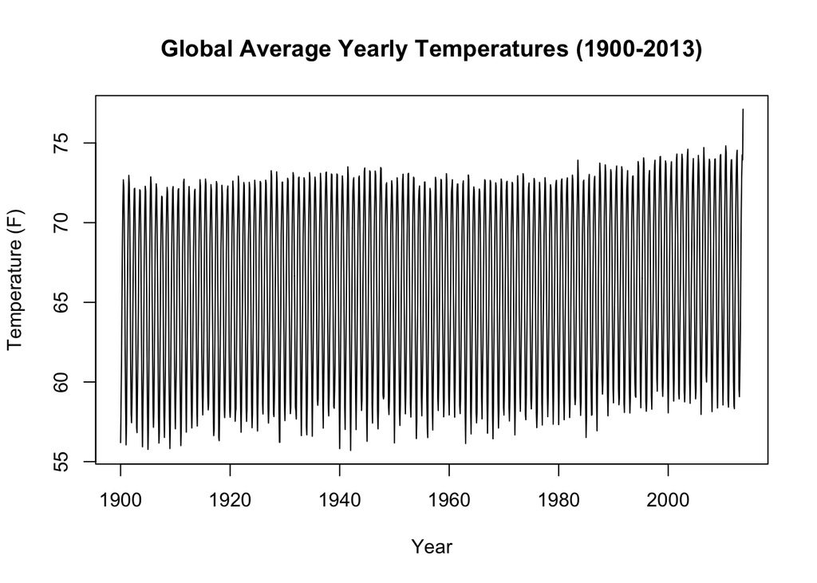

```r
#Data Cleaning and Preparation.

data$dt <- as.Date(data$dt)

data <- data |>
  group_by(dt) |>
  summarise(AverageTemperature = mean(AverageTemperature, na.rm = TRUE)) |>
  filter(!is.na(AverageTemperature)) |>
  filter(dt >= as.Date("1900-01-01"))








#temperature is in celsius so we will conver to farenheit

data$AverageTemperature <- (data$AverageTemperature * 9/5) + 32

#cast temperature as time series object

data <- ts(data$AverageTemperature, start=c(1900,1), frequency=12)



# time series plot
#plot data
plot(data, main="Global Average Yearly Temperatures (1900-2013)", ylab="Temperature (F)", xlab="Year")
```

From time series plot we can see there is clear seasonility and upward trend in the data. With a large spike especially near the end of the time series .

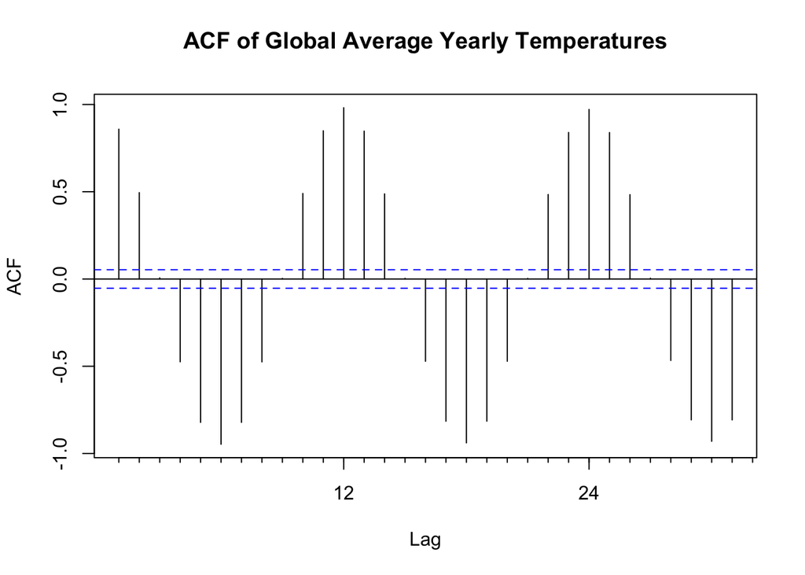

```r
# acf plot
Acf(data, main="ACF of Global Average Yearly Temperatures")
```

From viewing the acf plot we can see strong positive auto correlatino at lag one and then slowley decay but there are spikes at intervals of lag 12 meaning the seasonal cycle is yearly . So the temperature is highly correalted with the same temperature but a year ago / 2 years ago / 3 years ago etc.

```r
#Min max median , 1st and 3rd quartile values of time series
summary(data)
```

```
##    Min. 1st Qu.  Median    Mean 3rd Qu.    Max.
##   55.71   60.84   66.37   65.90   71.16   77.12
```

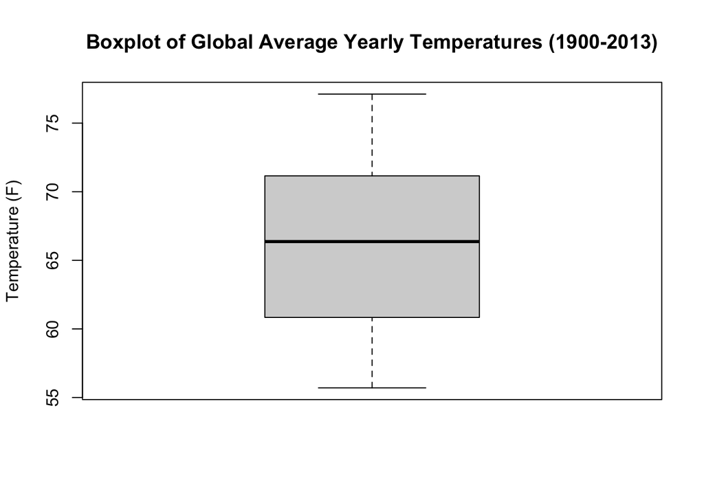

```r
# box plot

boxplot(data, main="Boxplot of Global Average Yearly Temperatures (1900-2013)", ylab="Temperature (F)")
```

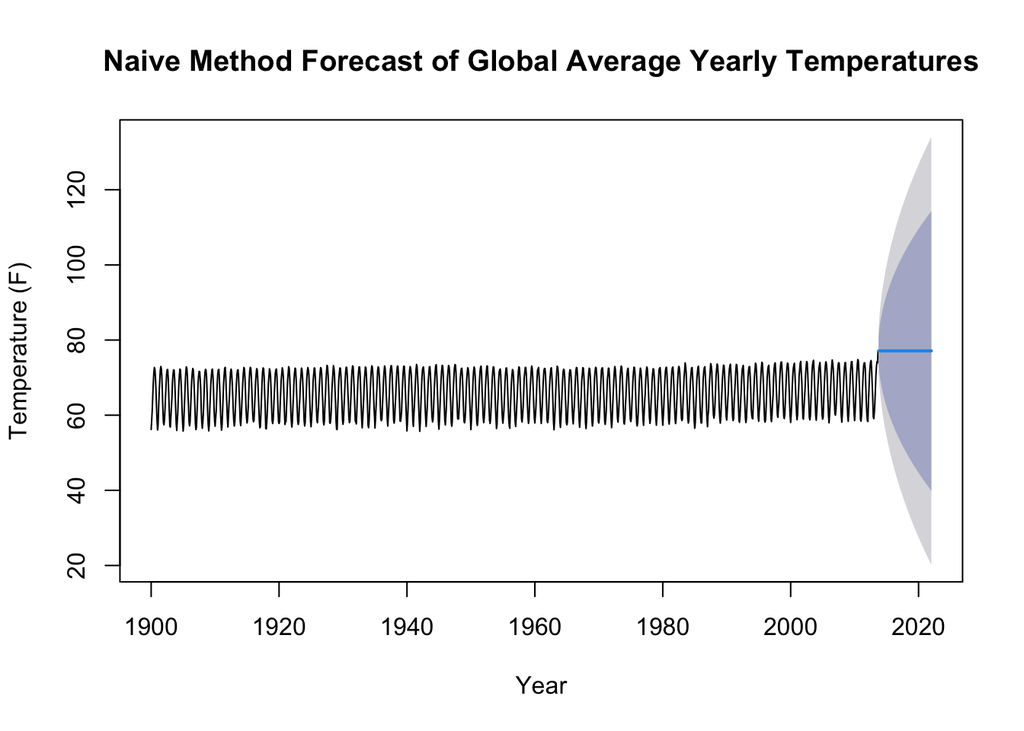

```r
#naive method
fit_naive <- naive(data, h=100)

#forecast 100 months

forecast_naive <- forecast(fit_naive, h=100)

# plot forecast

plot(forecast_naive, main="Naive Method Forecast of Global Average Yearly Temperatures", ylab="Temperature (F)", xlab="Year")
```

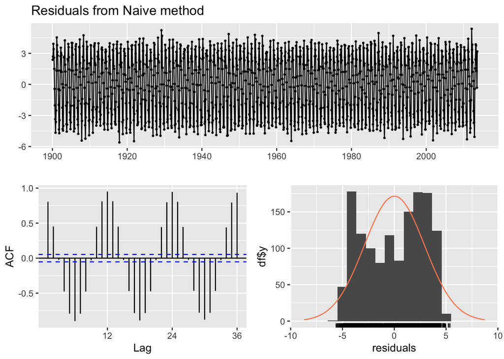

```
##
##  Ljung-Box test
##
## data:  Residuals from Naive method
## Q* = 14075, df = 24, p-value < 2.2e-16
##
## Model df: 0.   Total lags used: 24
```

```r
#plot of residuals
checkresiduals(fit_naive)
```

We can see the resiudals are roughly cnetered around 0 but not a clean normal distirbution there are spikes in the ireduals and the acf plot of the residuals shows some correlation at lag 1 and lag 12 meaning the model has not captured all the information in the data. And we can still see seasonility in the residuals

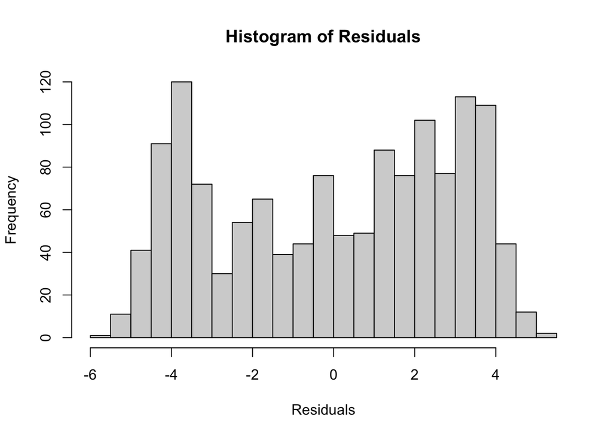

```r
# histogram plot of residulas
hist(fit_naive$residuals, main="Histogram of Residuals", xlab="Residuals", breaks=20)
```

The plot indicates the residuals are not normally distirbuted there are sppiked in the residuals it is not clean normal distirbution.

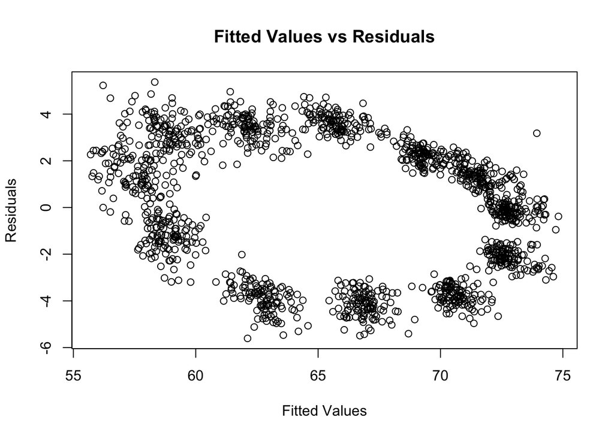

```r
# fitted values vs residuals
plot(fit_naive$fitted, fit_naive$residuals, main="Fitted Values vs Residuals", xlab="Fitted Values", ylab="Residuals")
```

From viewing the plot we can see there is a strong patter in the distinct oval shape meaning the model has not captured all the information in the data. There is still strong seasonlity in the residuals.

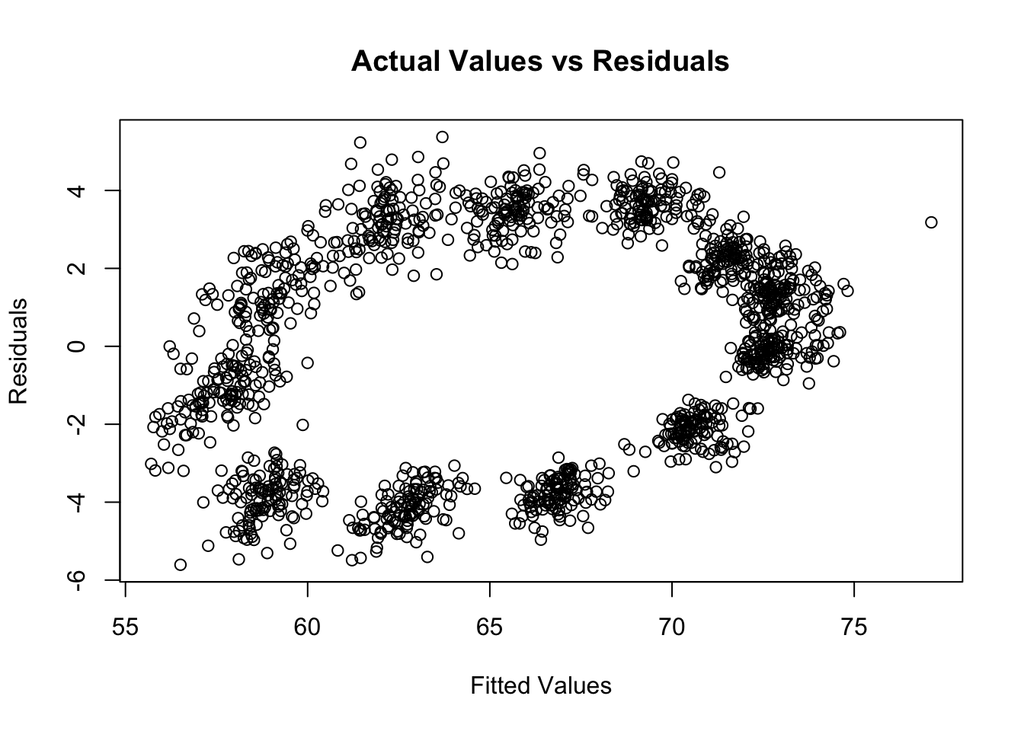

```r
# plot of actual values vs residuals
plot(data, fit_naive$residuals, main="Actual Values vs Residuals", xlab="Fitted Values", ylab="Residuals")
```

Again distinct oval shape from viewing actual values vs residuals showing there is still strong seasonlity in the residuals.

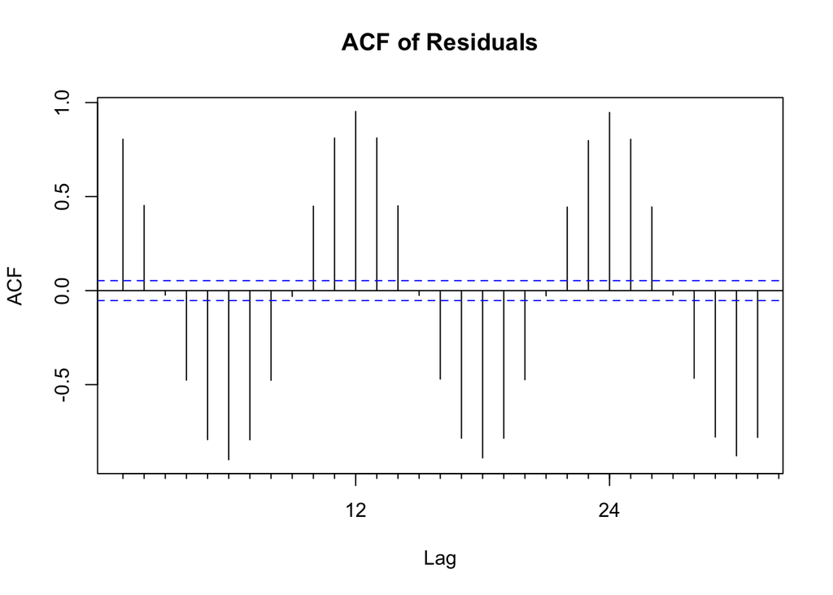

```r
# acf plot of residuals
Acf(fit_naive$residuals, main="ACF of Residuals")
```

From viewing the acf plot of the residuals we can see there is still strong correlation at each yearly interval meaning the naive model has not captured all the information in the data.

```r
# five measures of accuracy
accuracy(fit_naive)
```

```
##                      ME     RMSE      MAE         MPE     MAPE     MASE
## Training set 0.01533843 2.904606 2.575189 -0.07809906 3.972769 4.729983
##                   ACF1
## Training set 0.8046955
```

```r
# forecast value for next year.
forecast_naive$mean[100]
```

```
## [1] 77.11717
```

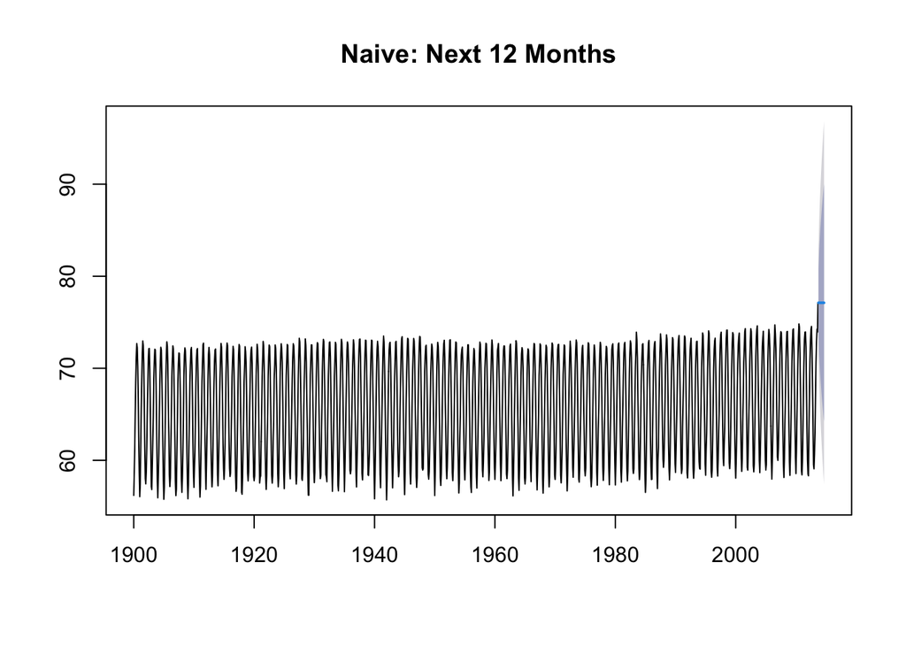

```r
# plot of one year forecast
fit_naive_12 <- naive(data, h = 12)
plot(fit_naive_12, main = "Naive: Next 12 Months")
```

```r
# numeric values:
fit_naive_12$mean
```

```
##           Jan      Feb      Mar      Apr      May      Jun      Jul      Aug
## 2013
## 2014 77.11717 77.11717 77.11717 77.11717 77.11717 77.11717 77.11717 77.11717
##           Sep      Oct      Nov      Dec
## 2013          77.11717 77.11717 77.11717
## 2014 77.11717
```

The forecast for the next year is 77.117 using naive . Naive method only predicts one value , the last value recorded so good baseline model but not too accurate .

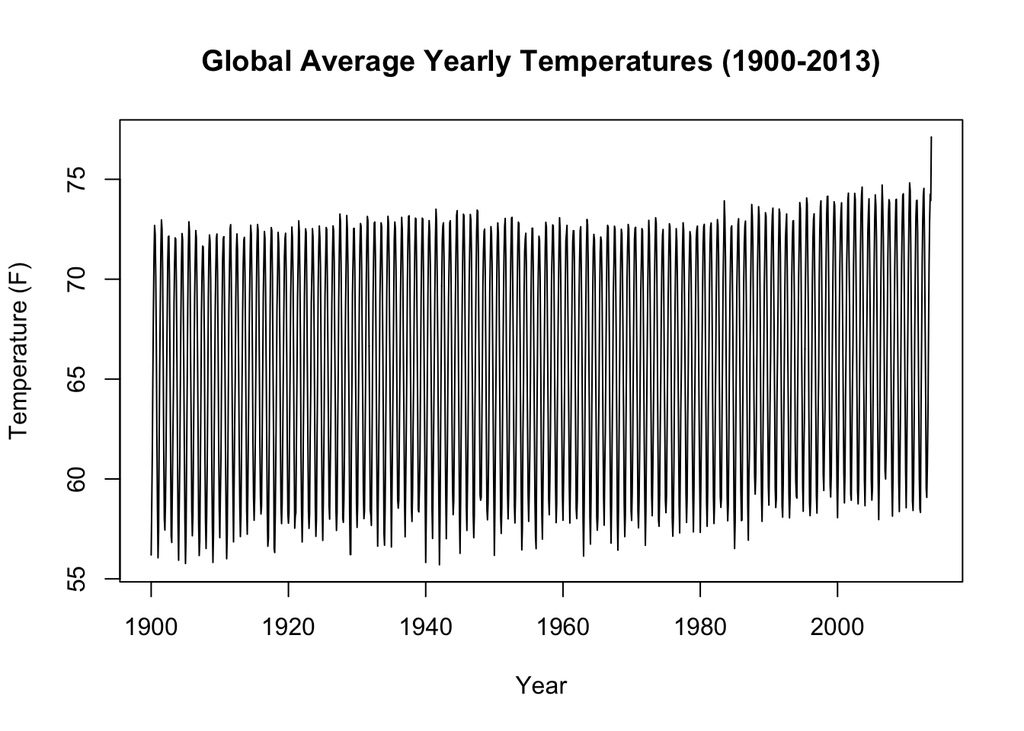

```r
# plot of data
plot(data, main="Global Average Yearly Temperatures (1900-2013)", ylab="Temperature (F)", xlab="Year")
```

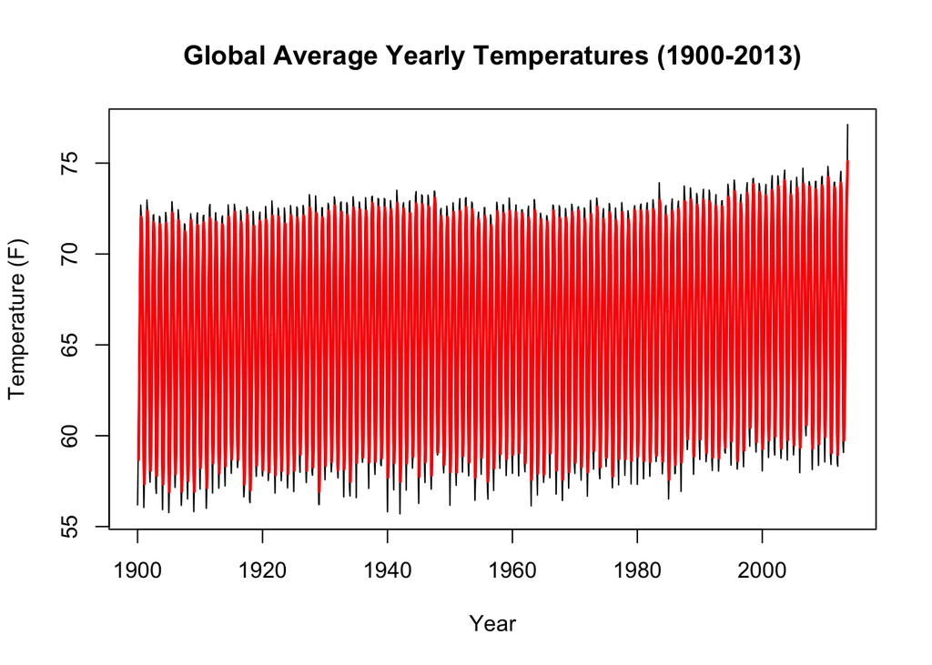

```r
# simply moving average order three on the plot above in red
plot(data, main="Global Average Yearly Temperatures (1900-2013)", ylab="Temperature (F)", xlab="Year")

lines(SMA(data, n=3), col="red", lwd=2)
```

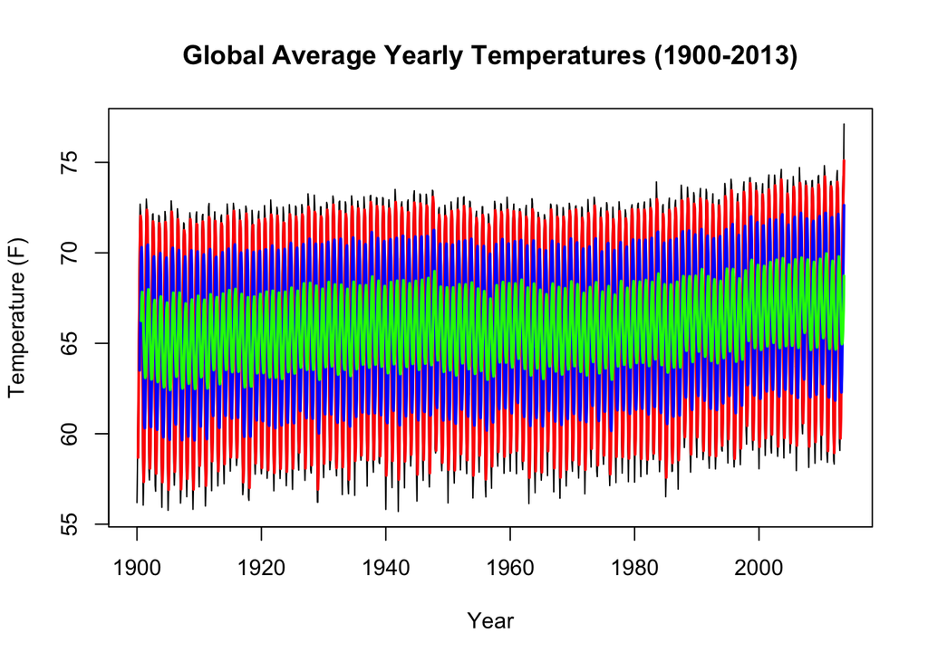

```r
# simply moving average order three on the plot above in red
plot(data, main="Global Average Yearly Temperatures (1900-2013)", ylab="Temperature (F)", xlab="Year")

lines(SMA(data, n=3), col="red", lwd=2)

lines(SMA(data, n=6), col="Blue", lwd=2)

lines(SMA(data, n=9), col="Green", lwd=2)
```

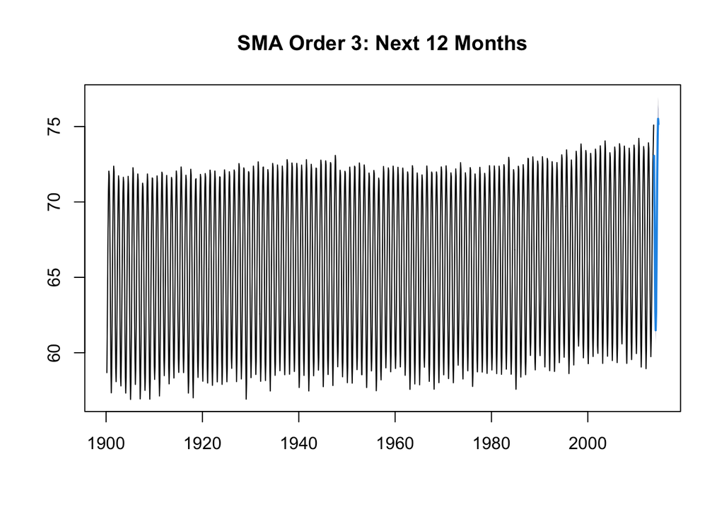

```r
# sma 3 forecast for next 12 months
fit_sma3 <- SMA(data, n=3)
# plot
plot(forecast(fit_sma3, h=12), main="SMA Order 3: Next 12 Months")
```

As moving average goes up it gets smoother but lags more behind the data.

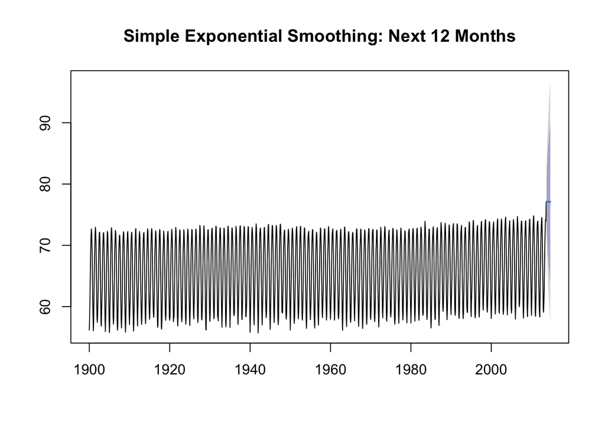

```r
# simple smoothing forecast for next 12 months for the time series
fit_ses <- ses(data, h=12)
# plot
plot(fit_ses, main="Simple Exponential Smoothing: Next 12 Months")
```

```r
# alpha value
fit_ses$model$par["alpha"]
```

```
##  alpha
## 0.9999
```

Alpha means the weight given to the most recent observation . The closer alpha is to 1 the more weight is given to the most recent observation. The closer alpha is to 0 the more weight is given to the past observations. Here alpha is 0.9999 meaning almost all weight is given to the most recent observation.

```r
# value of intial state
fit_ses$model$par["l"]
```

```
##       l
## 56.1957
```

```r
#value of sigma
fit_ses$model$sigma2
```

```
## [1] 8.444284
```

Sigma is the variance of the residuals . Here sigma is 8.444284.

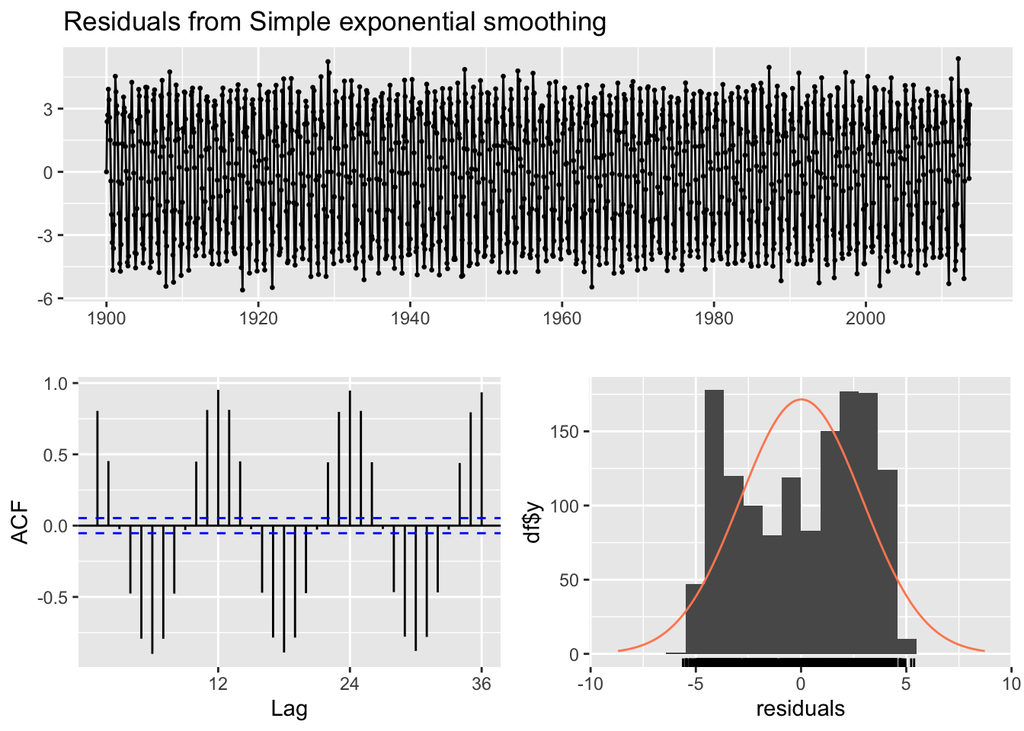

```
##
##  Ljung-Box test
##
## data:  Residuals from Simple exponential smoothing
## Q* = 14085, df = 24, p-value < 2.2e-16
##
## Model df: 0.   Total lags used: 24
```

```r
# plot of residuals
checkresiduals(fit_ses)
```

Similar to the naive methods there is still seasonility present from these various plot of the resiauls . Roughly centered near 0 but there are spikes. acf still shows spikes at lag 1 , 12, 24, 36. And we can see still the cyclility in the residuals.

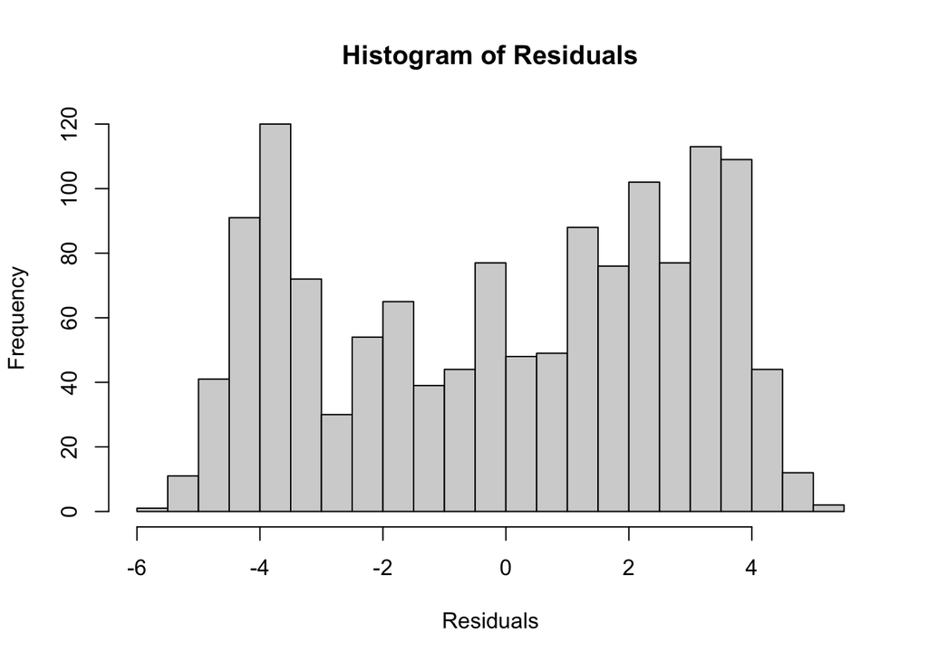

```r
# histogram plot of residuals
hist(fit_ses$residuals, main="Histogram of Residuals", xlab="Residuals", breaks=20)
```

We can see clearly it is not normally distributed from this better histrogram of residuals of using SES model

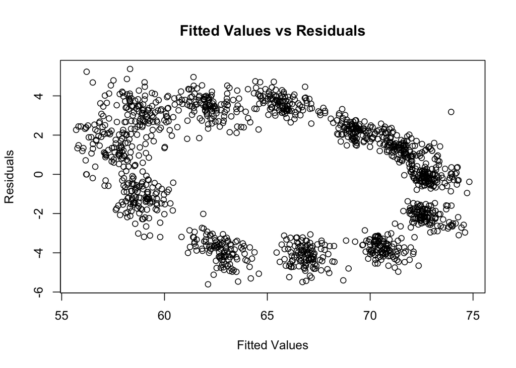

```r
# fitted values vs residuals
plot(fit_ses$fitted, fit_ses$residuals, main="Fitted Values vs Residuals", xlab="Fitted Values", ylab="Residuals")
```

Again distinct oval shape from viewing fitted values vs residuals showing there is still strong seasonlity

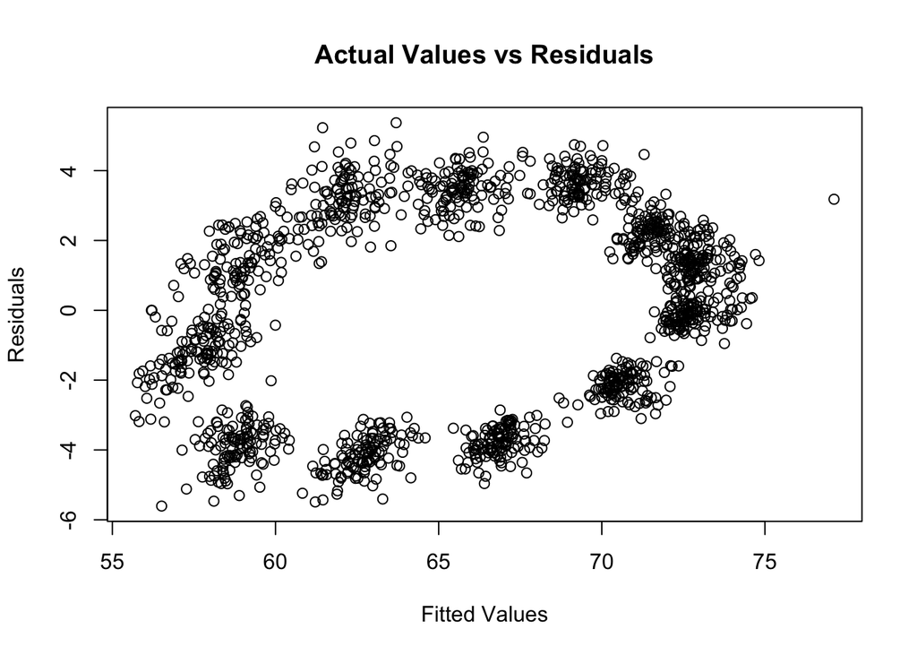

```r
# plot of actual values vs residuals

plot(data, fit_ses$residuals, main="Actual Values vs Residuals", xlab="Fitted Values", ylab="Residuals")
```

Again distinct oval shape from viewing actual values vs residuals showing there is still strong seasonlity

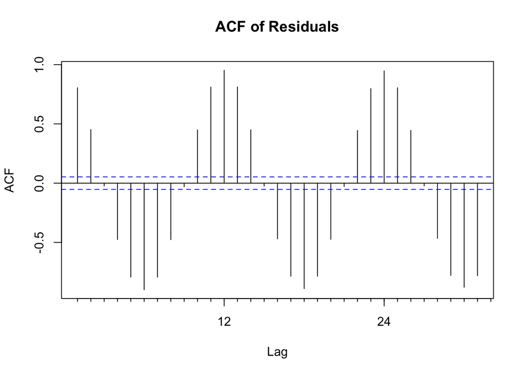

```r
# acf plot of residuals
Acf(fit_ses$residuals, main="ACF of Residuals")
```

From viewing the acf plot of the residuals we can see there is still strong correlation at ;age 1 , 12, 24, 36 meaning the ses model has not captured all the information in the data. there is still seasonliltiy that has not been captured.

```r
# five measures of accuracy
accuracy(fit_ses)
```

```
##                      ME     RMSE      MAE         MPE     MAPE     MASE
## Training set 0.01532839 2.903775 2.573523 -0.07806633 3.970199 4.726922
##                  ACF1
## Training set 0.804708
```

```r
# forecast value for next year.
fit_ses$mean[12]
```

```
## [1] 77.11685
```

The forecast for the next year using ses is 77.117 . Similar to naive method as ses with alpha near 1 is basically same as naive method.

Accuracy is not too bad of SES model the mape is 3.97% . RMSE IS 2.90

```r
# holt winters forecast for next 12 months
fit_hw <- hw(data, seasonal="additive", h=12)
```

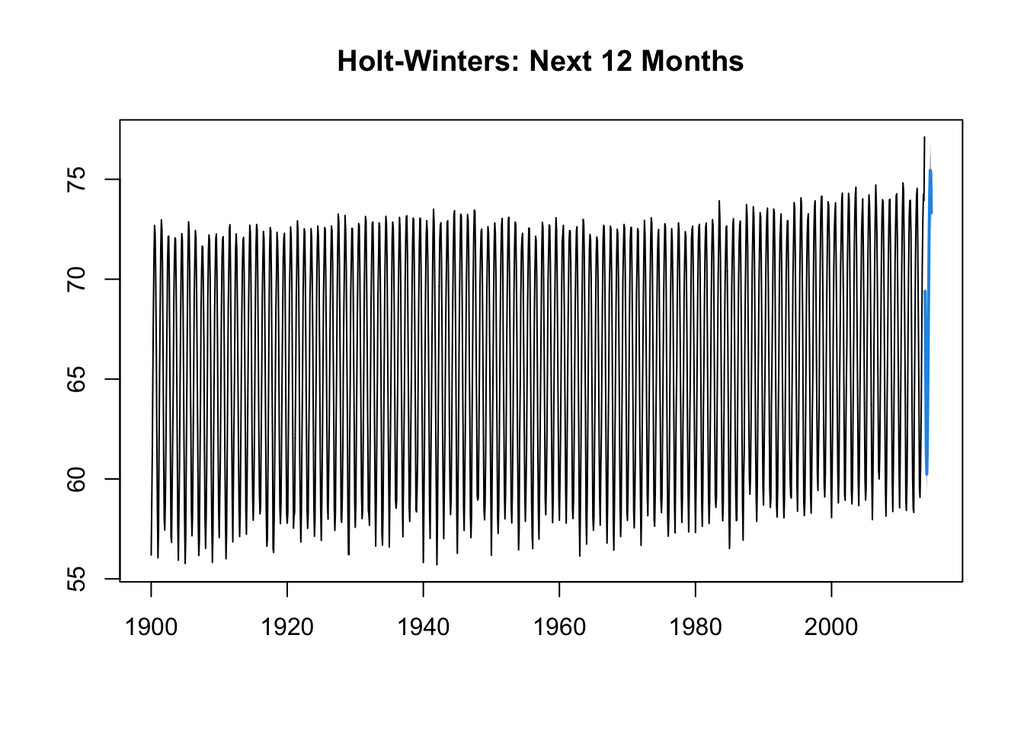

```r
# plot
plot(fit_hw, main="Holt-Winters: Next 12 Months")
```

```r
# value of alpha
fit_hw$model$par["alpha"]
```

```
##     alpha
## 0.2528433
```

Alpha is 0.25 in holt winters meaning 25% weight is given to the most recent observation and 75% weight is given to the past observations.

```r
# value of beta
fit_hw$model$par["beta"]
```

```
##         beta
## 0.0001186668
```

Beta is 0.00011 meaning almost no weight is given to the trend component.

```r
# value of gamma
fit_hw$model$par["gamma"]
```

```
##      gamma
## 0.03394109
```

Gamma is 0.03 meaning 3% weight is given to the seasonal component and 97% weight is given to the past seasonal components.

```r
# value of intial states for level trend and seasonility
fit_hw$model$par[c("l", "b", "s1", "s2", "s3", "s4", "s5", "s6", "s7", "s8", "s9", "s10", "s11","s12")]
```

```
##            l            b           s1           s2           s3           s4
## 65.243657304  0.000853614 -3.129037322  1.115721926  4.853030600  6.932510341
##           s5           s6           s7           s8           s9          s10
##  7.103689776  5.737751879  3.437725880 -0.104576200 -3.586888401 -6.875668819
##         <NA>         <NA>
##           NA           NA
```

Level is 65 . Trend is 0.00085 . And we can see the seasonal components here for each one . Trend is almost 0 meaning there is almost no trend component in the holt winters model.

```r
# value of sigma
fit_hw$model$sigma2
```

```
## [1] 0.2553523
```

Sigma is 0.255 , which is the variance of the residuals .

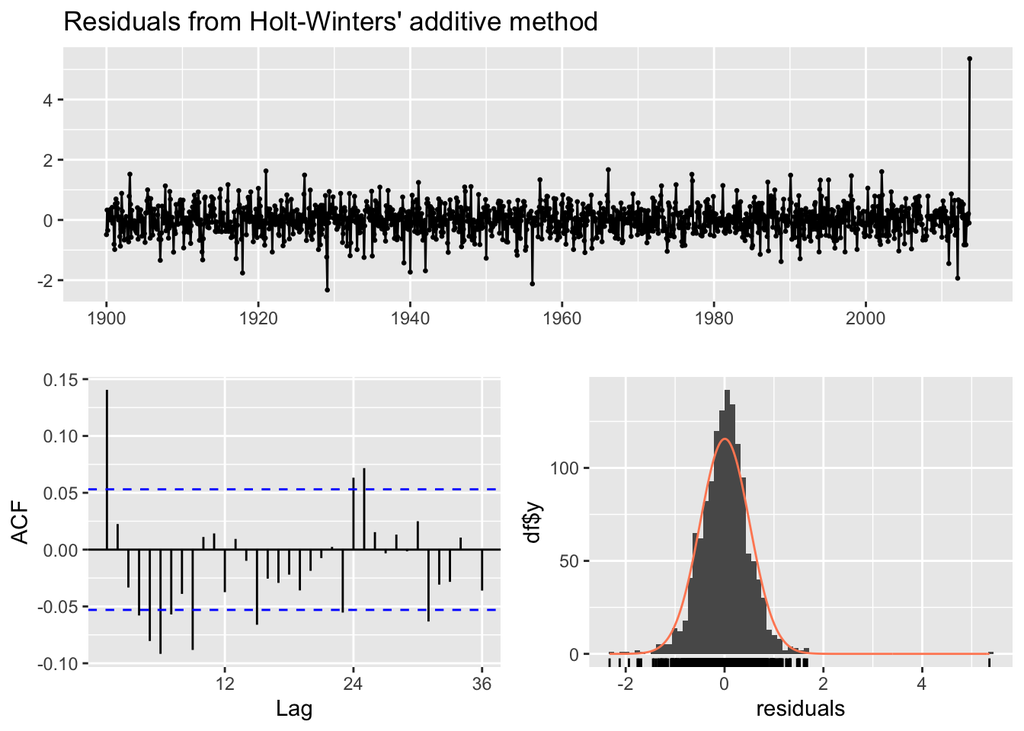

```
##
##  Ljung-Box test
##
## data:  Residuals from Holt-Winters' additive method
## Q* = 95.173, df = 24, p-value = 1.975e-10
##
## Model df: 0.   Total lags used: 24
```

```r
# plot of residuals
checkresiduals(fit_hw)
```

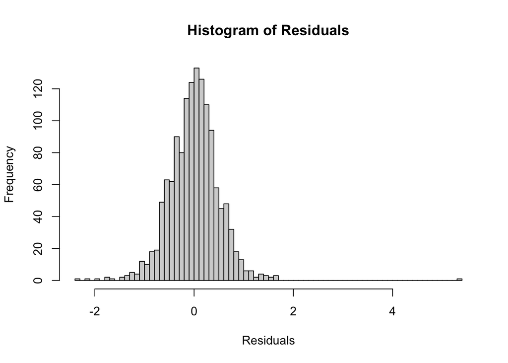

```r
# histogram plot of residuals

hist(fit_hw$residuals, main="Histogram of Residuals", xlab="Residuals", breaks=100)
```

Yes the histogram shows the residuals are normally distribued

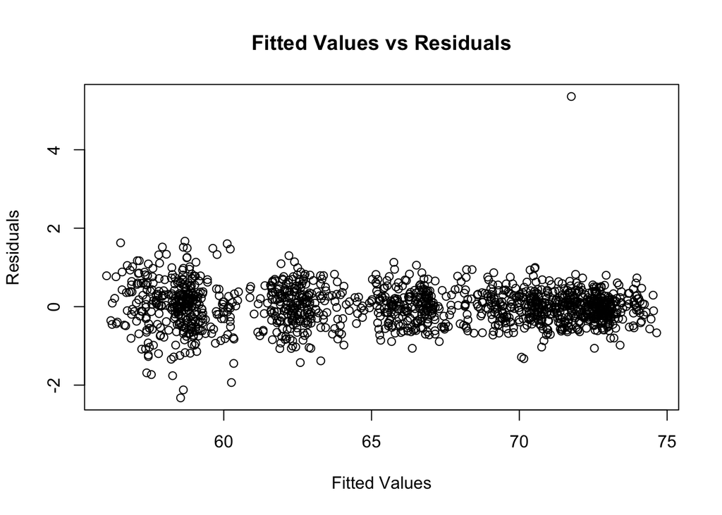

```r
# fitted values vs residuals

plot(fit_hw$fitted, fit_hw$residuals, main="Fitted Values vs Residuals", xlab="Fitted Values", ylab="Residuals")
```

We can see the reisduals vs fitted values are rougly centered arond 0 against all predicted values .

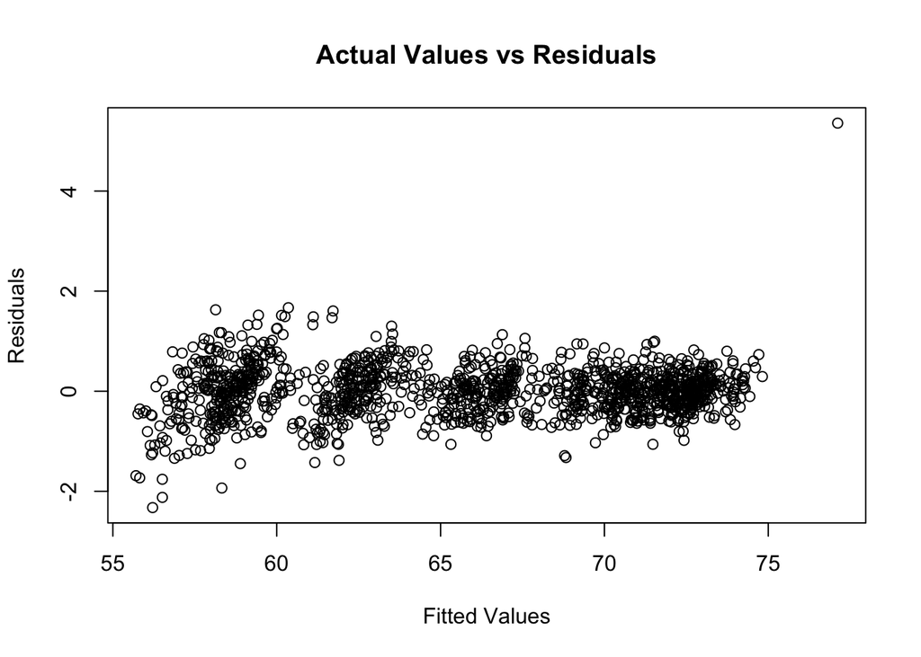

```r
# plot of actual values vs residuals


plot(data, fit_hw$residuals, main="Actual Values vs Residuals", xlab="Fitted Values", ylab="Residuals")
```

We can see the reisduals vs actual values are rougly centered arond 0 against all actual values .

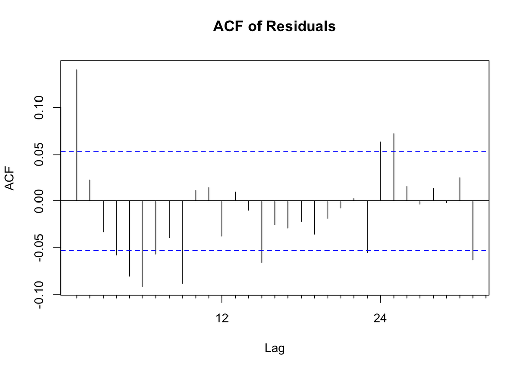

```r
# acf plot of residuals
Acf(fit_hw$residuals, main="ACF of Residuals")
```

Compared to the other models the acf plot of residuals is much better now , not as many signifcant spikes only a few now

```r
# five measures of accuracy
accuracy(fit_hw)
```

```
##                       ME      RMSE       MAE         MPE      MAPE      MASE
## Training set 0.005825669 0.5023536 0.3707386 0.005339084 0.5782372 0.6809547
##                   ACF1
## Training set 0.1405873
```

We can see the mape is the best out of all models we have seen so far it is 0.57 in this in sample performance

```r
# forecast value for next year.
fit_hw$mean[12]
```

```
## [1] 73.31725
```

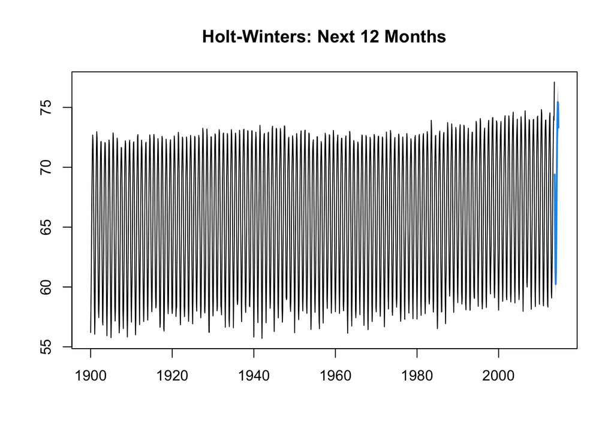

```r
#plot
plot(fit_hw, main="Holt-Winters: Next 12 Months")
```

Accruacy is good as described before rmse is low , mae , and mape all look very good in sample performance.

```r
# time series value in one year
fit_hw$mean[12]
```

```
## [1] 73.31725
```

Holt winters is the best model so far from these

```r
# table of all forecast methods above with their accuracy measures

methods <- c("Naive", "SES", "Holt-Winters")
accuracy_measures <- rbind(accuracy(fit_naive), accuracy(fit_ses), accuracy(fit_hw))
accuracy_table <- data.frame(Method = methods, accuracy_measures)
print(accuracy_table)
```

```
##                      Method          ME      RMSE       MAE          MPE
## Training.set          Naive 0.015338435 2.9046059 2.5751892 -0.078099058
## Training.set.1          SES 0.015328388 2.9037755 2.5735226 -0.078066328
## Training.set.2 Holt-Winters 0.005825669 0.5023536 0.3707386  0.005339084
##                     MAPE      MASE      ACF1
## Training.set   3.9727692 4.7299833 0.8046955
## Training.set.1 3.9701991 4.7269222 0.8047080
## Training.set.2 0.5782372 0.6809547 0.1405873
```

For Mean error Winters is best and naive is worse . For rmse hw is best and naive is worst. For mae hw is best naive is worst. for mpe hw is best and naive is worst. For mape hw is best and naive is worst. for mase hw is best and naive is worst. for acf1 hw is best and ses is worst.

Naive uses last value for prediction

SES uses weighted average of all past values with more weight on recent values

Holt winters uses level , trend , and seasonal components to make prediction and comes in best out of all three models. We have used additive seasonal component as the seasonality is roughly constant over time. And specified the seasonality is yearly as seen in the acf plot. Holt winters captures the information the best as shown in the residual analysis and accuracy measures so it is best model then SES then Naive based on MAPE.

Overall we can see the HW - Holt winters models is best from the metrics such as MAPE , RMSE , MAE as well as analysis of residuals it had normal distirbution around 0 , minimial signifcant spikes in acf , and no distinct patterns in the residual plots.

Rank of forecast methods from best to worst : 1. Holt Winters 2. SES 3. Naive